# Bivariate Relationships

February 11, 2022

# Bivariate

- So far, we have been analyzing summary statistics that describe aspects of a single list of numbers
- Frequently, however, we are interested in how variables behave together
  - Measuring the relationship (correlation)
  - Modeling the relationship (regression)

# Motivating Example

- Smoking and Lung Capacity
  - Suppose, for example, we wanted to investigate the relationship between cigarette smoking and lung capacity
  - We might ask a group of people about their smoking habits, and measure their lung capacities

# Smoking and Lung Capacity

| cigarettes | lung_capacity |
| --- | --- |
| 0 | 45 |
| 5 | 42 |
| 10 | 33 |
| 15 | 31 |
| 20 | 29 |

# Visualizing

- With R or any other statistics software, we can produce a scatterplot, like this one.

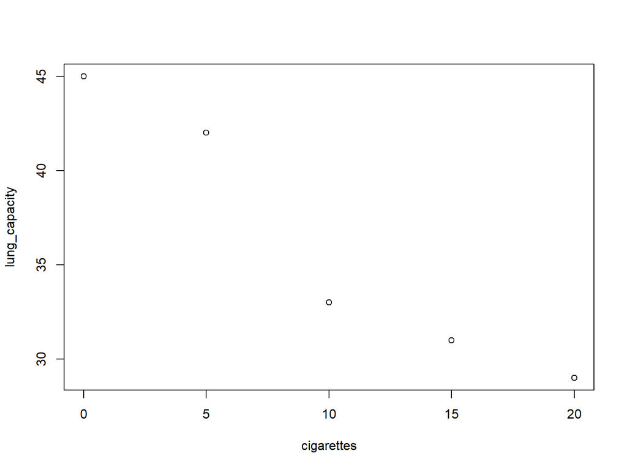

```r
plot(smoking)
```

# Or this one

- A scatterplot shows the relationship between two quantitative variables that are measured on the same individuals.
  - The values of one variable appear on the horizontal axis,
  - and the values of the other variable appear on the vertical axis.
  - Each individual in the data appears as the point in the plot fixed by the values of both variables for that individual.

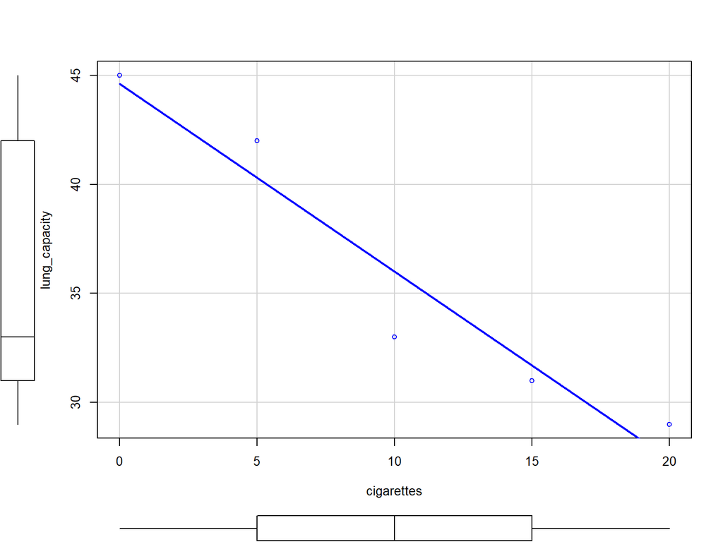

```r
library(car)
scatterplot(lung_capacity~cigarettes,data=smoking)
```

# Or this one

- Always plot the explanatory variable, if there is one, on the horizontal axis (the x-axis) of a scatterplot
  - if there is no explanatory-response distinction, either variable can go on the horizontal axis.

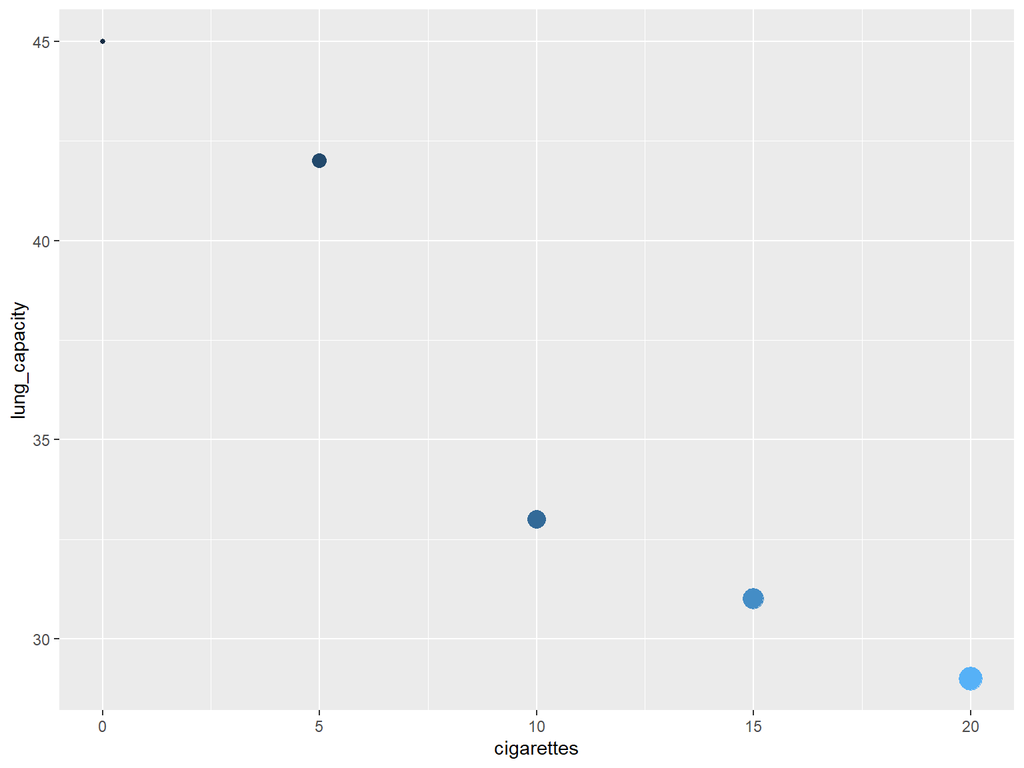

```r
library(ggplot2)
library(ggExtra)

# classic plot :
p=ggplot(smoking, aes(x=cigarettes, y=lung_capacity, color=cigarettes, size=cigarettes)) +
      geom_point() +
      theme(legend.position="none")
p
```

# Or this one

- We can see from the graph that as smoking goes up, lung capacity tends to go down.

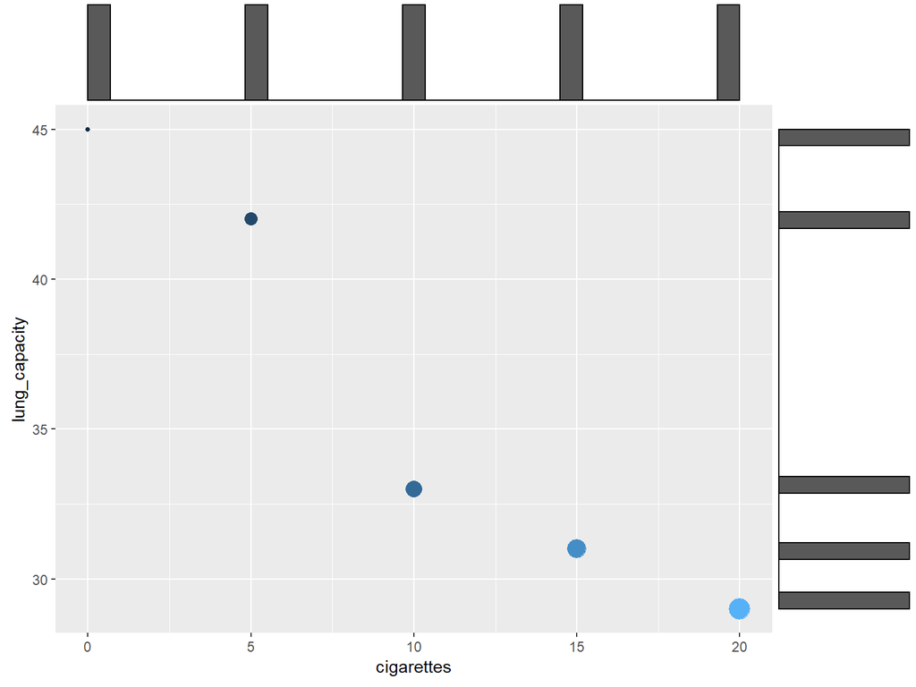

```r
# with marginal histogram
ggMarginal(p, type="histogram")
```

# Or this one

- Here, the two variables covary in opposite directions.
- This is a negative relationship

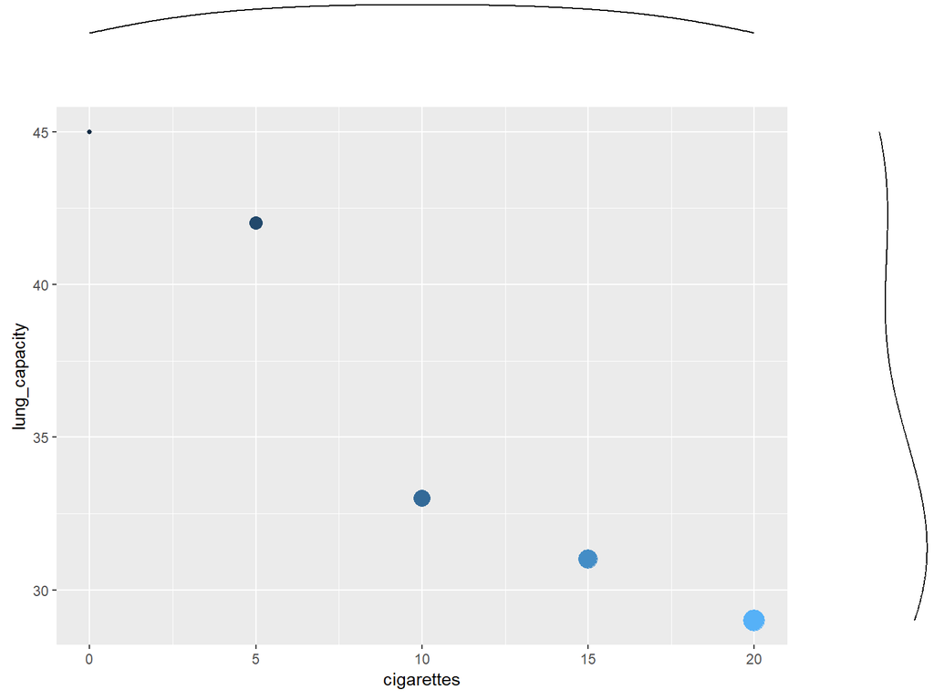

```r
# marginal density
ggMarginal(p, type="density")
```

# Scatter Plots

- In any graph of data, look for the overall pattern and for striking deviations from that pattern.
- You can describe the overall pattern of a scatterplot by the
  - direction (positive or negative),
  - form, and
  - strength of the relationship.

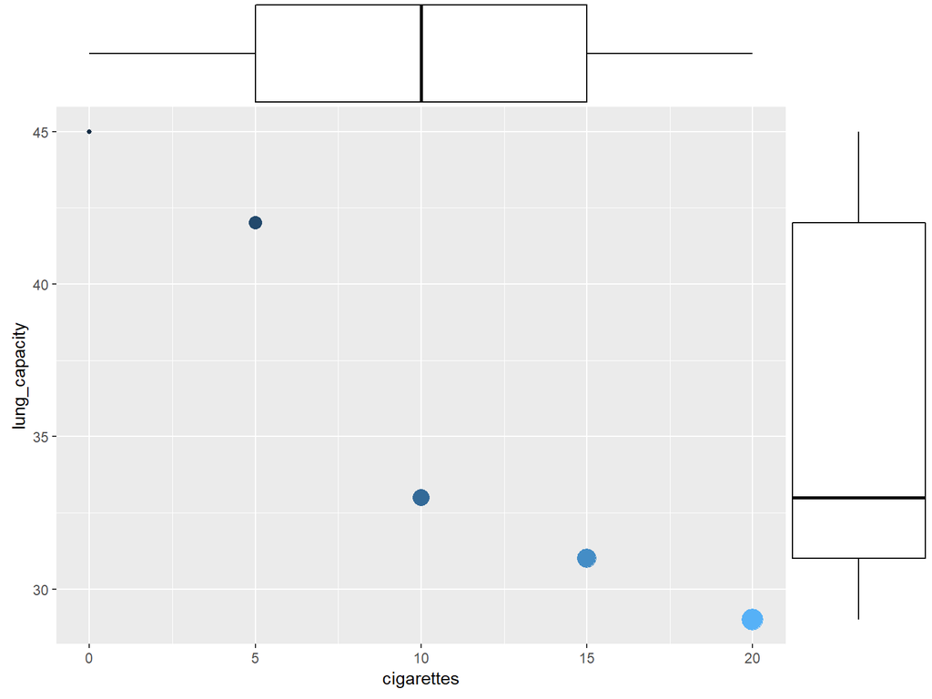

```r
# marginal boxplot
ggMarginal(p, type="boxplot")
```

- More examples https://www.statmethods.net/graphs/scatterplot.html

# Direction of Association

- Two variables are *positively associated* when above-average values of one tend to accompany above-average values of the other, and below-average values also tend to occur together.
- Two variables are *negatively associated* when above-average values of one tend to accompany below-average values of the other, and vice versa.

# Strength of the Relationship

- We now examine two statistics:
  - covariance and
  - correlation, for quantifying how variables covary.

# Covariance

- Covariance is a measure of how much two random variables vary together.
- When two variables covary in opposite directions, as smoking and lung capacity do,
  - values tend to be on opposite sides of the group mean.
  - That is, when smoking is above its group mean,
  - lung capacity tends to be below its group mean.
- Consequently, by averaging the product of deviation scores, we can obtain a measure of how the variables vary together.

# Sample Covariance

- Sample covariance between X and Y is an estimate of that average (cross-) product of deviation scores in the population

$s_{x,y}=\frac{1}{n-1}\sum\limits^{n}_{i=1}(x_{i}-\bar{x})(y_{i}-\bar{y})$

- A more computationally convenient formula:

$s_{x,y}=\frac{1}{n-1}(\sum\limits^{n}_{i=1}x_{i}y_{i}-\frac{\sum^{n}_{i=1}x_{i}\sum^{n}_{i=1}y_{i}}{n})$

- Useful fact: the variance of a variable is its covariance with itself.

$s^{2}=s_{x,x}=\frac{1}{n-1}\sum\limits^{n}_{i=1}((x_{i}-\bar{x})(x_{i}-\bar{x}))$

# Computing Covariance

- If we wanted to compute the covariance for smoking and lung capacity, we can save ourselves some heartache.
- Rather than finding each deviation from the mean for x and y

```r
covariance_calc=data.frame(X=smoking$cigarettes,Y=smoking$lung_capacity)

# find x_i-x_bar
covariance_calc$dx=covariance_calc$X-mean(covariance_calc$X)

# find y_i-y_bar
covariance_calc$dy=covariance_calc$Y-mean(covariance_calc$Y)
```

- and then finding their product

```r
#cross multiply x deviations and y deviations
covariance_calc$dxdy=covariance_calc$dy*covariance_calc$dx

# cross multi X and Y
covariance_calc$xy=covariance_calc$Y*covariance_calc$X
```

- Giving these values

| X | Y | dx | dy | dxdy | xy |
| --- | --- | --- | --- | --- | --- |
| 0 | 45 | -10 | 9 | -90 | 0 |
| 5 | 42 | -5 | 6 | -30 | 210 |
| 10 | 33 | 0 | -3 | 0 | 330 |
| 15 | 31 | 5 | -5 | -25 | 465 |
| 20 | 29 | 10 | -7 | -70 | 580 |

- We’d then sum the dXdY column and get -215, and we then compute the covariance as:

$s_{x,y}=\frac{1}{n-1}\sum\limits^{n}_{i=1}(x_{i}-\bar{x})(y_{i}-\bar{y})= \frac{-215}{5-1}=-53.75$

# Alternative Computation

- We can compute $\sum x=50$, $\sum y=180$, $\sum xy=1585$, and n, and use that easier equation

$s_{x,y}=\frac{1}{n-1}(\sum x_{i}y_{i}-\frac{\sum x_{i}\sum y_{i}}{n})$

$=\frac{1}{5-1}(1585-\frac{50\times180}{5})$

$=\frac{1}{4}(1585-\frac{9000}{5})$

$=\frac{1}{4}(1585-1800)$

$=\frac{1}{4}(-215)$

$=-53.75$

# Covariance in R

```r
cov(smoking)
```

```
##               cigarettes lung_capacity
## cigarettes         62.50        -53.75
## lung_capacity     -53.75         50.00
```

```r
cov(smoking)[1,2]
```

```
## [1] -53.75
```

```r
var(smoking$cigarettes)
```

```
## [1] 62.5
```

# Covariance

- Although covariance is an extremely important concept and is the cornerstone of many advanced methods (ANOVA, ANCOVA, SEM, regression, etc)
- it has interpretation problems just like variance
- it isn’t in a meaningful scale
- it tells us whether a relationship is positive or negative
  - but not much more than that.

# Covariance Scaling

- is -53.75 a strong relationship?
  - it depends on the scale
- If we convert cigarettes into packs, the relationship hasn’t changed.
- but the covariance has…

```r
smoking$packs=smoking$cigarettes/20

cov(smoking$packs,smoking$lung_capacity)
```

```
## [1] -2.6875
```

- The value is, in a sense, “polluted by the metric of the numbers.”
- Depending on the scale of the data, the absolute value of the covariance can be very large or very small

# Standardizing Covariance

- We can take the scale out of the covariance.
- What happens if we use z-scores instead of raw deviations?
- Remember, that z-scores are also a measure of deviations
- This is called the (Pearson) Correlation Coefficient

# Correlation Coefficient

- The sample correlation is the sum of cross-products of z-scores divided by n-1:

$r_{x,y}=\frac{1}{n-1}\sum\limits^{n}_{i=1}(Z_{x_{i}}\times Z_{y_{i}})$

$\rho_{x,y}=\frac{1}{n}\sum\limits^{n}_{i=1}(Z_{x_{i}}\times Z_{y_{i}})$

# Formulae for Correlation

- We can think of a correlation coefficient as a covariance with the standard deviations factored out:

$r_{x,y}=\frac{s_{x,y}}{s_{x}\times s_{y}}$

- we can think of covariance as a correlation with the standard deviations put back in.

$s_{x,y}=r_{x,y}s_{x}s_{y}$

# Properties of r

- Notation
  - Sample Statistic r
  - Population Parameter $\rho$
    - pronounced row, but spelt rho
- Transformation
  - r is the same regardless of how the values are measured.
  - Height in inches and centemeters lead to the same r

```r
if (!require("HistData")) install.packages("HistData") ## Installs library if missing
library(ggplot2)
library(grid)
library(gridExtra)
# in inches
summary(Galton)
```

```
##      parent          child
##  Min.   :64.00   Min.   :61.70
##  1st Qu.:67.50   1st Qu.:66.20
##  Median :68.50   Median :68.20
##  Mean   :68.31   Mean   :68.09
##  3rd Qu.:69.50   3rd Qu.:70.20
##  Max.   :73.00   Max.   :73.70
```

```r
attach(Galton)          # attaches the dataset
plotin=ggplot(Galton, aes(x=parent, y=child)) + geom_point(size=2, pch=21,fill='red')
cor(child,parent)
```

```
## [1] 0.4587624
```

```r
detach(Galton)          # Remember to detach you dataset!

# in centimeters
Galton_cm=Galton*2.54
summary(Galton_cm)
```

```
##      parent          child
##  Min.   :162.6   Min.   :156.7
##  1st Qu.:171.4   1st Qu.:168.1
##  Median :174.0   Median :173.2
##  Mean   :173.5   Mean   :172.9
##  3rd Qu.:176.5   3rd Qu.:178.3
##  Max.   :185.4   Max.   :187.2
```

```r
attach(Galton_cm)           # attaches the dataset
plotcm=ggplot(Galton_cm, aes(x=parent, y=child)) + geom_point(size=2, pch=21,fill='red')

cor(child,parent)
```

```
## [1] 0.4587624
```

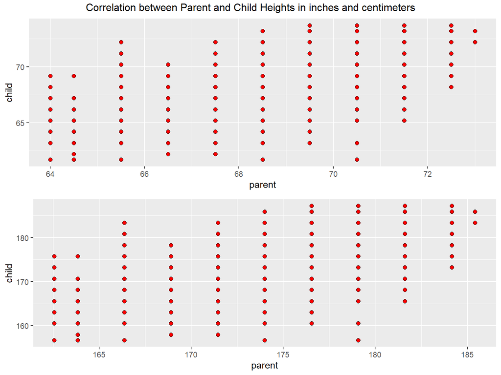

```r
detach(Galton_cm)           # Remember to detach you dataset!

grid.arrange(plotin, plotcm, top='Correlation between Parent and Child Heights in inches and centimeters')
```

# Properties of r

- r ranges from -1 to 1 [-1,1]
  - |r| indicates the size of the relationship
  - r>0 indicates positive relationship (0,1]
  - r<0 indicates negative relationship [-1,0)
  - r is symmetric
    - $r_{x,y}=r_{y,x}$

# Correlation Magnitude

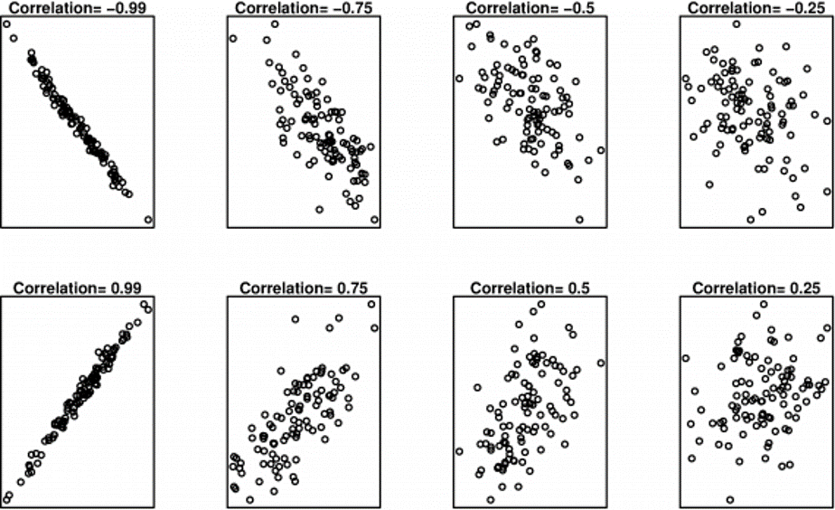

# Correlation Interpretation

- Perfect
  - Exactly –1. A perfect downhill (negative) linear relationship
  - Exactly +1. A perfect uphill (positive) linear relationship
- Strong
  - -0.70. A strong downhill (negative) linear relationship
  - +0.70. A strong uphill (positive) linear relationship
- Moderate
  - –0.50. A moderate downhill (negative) relationship
  - +0.50. A moderate uphill (positive) relationship
- Small
  - –0.30. A small downhill (negative) linear relationship
  - +0.30. A small uphill (positive) linear relationship
- Develop your correlation intuition http://guessthecorrelation.com/

# Linear Relationship

- The correlation quantifies the linear association.
- If your data aren’t linear, then the correlation can be misleading.
- If your data have outliers, then the correlation can be misleading.

# Anscombe’s Quartet

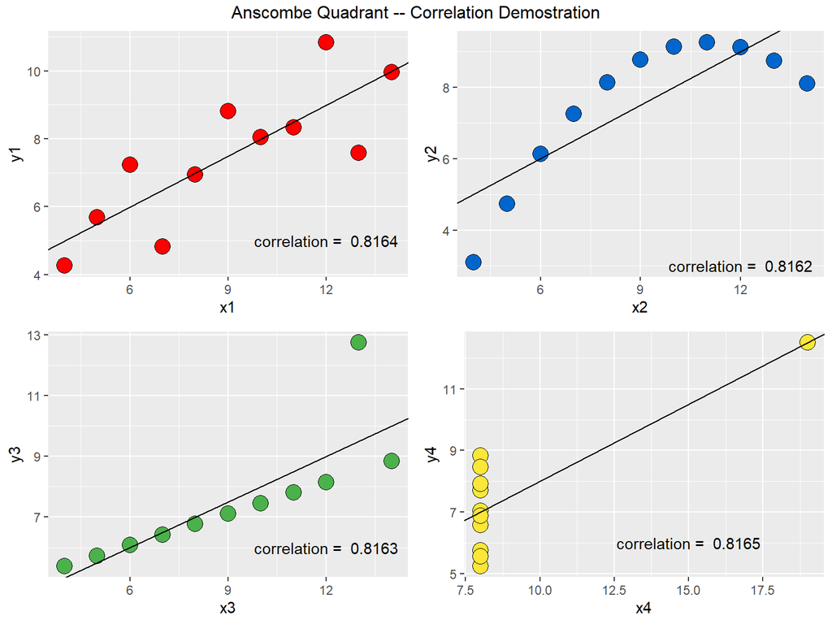

- Anscombe’s Quartet comprises four datasets that have nearly identical simple descriptive statistics, yet appear very different when graphed.
- These data were constructed in 1973 by the statistician Francis Anscombe (1973) .
- Demonstrates the importance of graphing data before analyzing it and the effect of outliers on statistical properties.
- It’s intended to counter the impression among statisticians that “numerical calculations are exact, but graphs are rough.”

# Anscombe’s Code

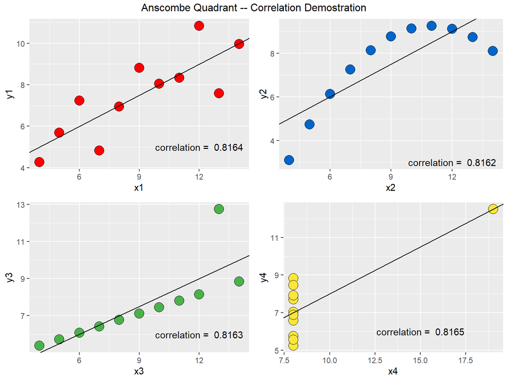

```r
cor1 <- format(cor(anscombe$x1, anscombe$y1), digits=4)
cor2 <- format(cor(anscombe$x2, anscombe$y2), digits=4)
cor3 <- format(cor(anscombe$x3, anscombe$y3), digits=4)
cor4 <- format(cor(anscombe$x4, anscombe$y4), digits=4)

#define the OLS regression
line1 <- lm(y1 ~ x1, data=anscombe)
line2 <- lm(y2 ~ x2, data=anscombe)
line3 <- lm(y3 ~ x3, data=anscombe)
line4 <- lm(y4 ~ x4, data=anscombe)

circle.size = 5
colors = list('red', '#0066CC', '#4BB14B', '#FCE638')

#plot1
plot1 <- ggplot(anscombe, aes(x=x1, y=y1)) + geom_point(size=circle.size, pch=21, fill=colors[[1]]) +
  geom_abline(intercept=line1$coefficients[1], slope=line1$coefficients[2]) +
  annotate("text", x = 12, y = 5, label = paste("correlation = ", cor1))

#plot2
plot2 <- ggplot(anscombe, aes(x=x2, y=y2)) + geom_point(size=circle.size, pch=21, fill=colors[[2]]) +
  geom_abline(intercept=line2$coefficients[1], slope=line2$coefficients[2]) +
  annotate("text", x = 12, y = 3, label = paste("correlation = ", cor2))

#plot3
plot3 <- ggplot(anscombe, aes(x=x3, y=y3)) + geom_point(size=circle.size, pch=21, fill=colors[[3]]) +
  geom_abline(intercept=line3$coefficients[1], slope=line3$coefficients[2]) +
  annotate("text", x = 12, y = 6, label = paste("correlation = ", cor3))

#plot4
plot4 <- ggplot(anscombe, aes(x=x4, y=y4)) + geom_point(size=circle.size, pch=21, fill=colors[[4]]) +
  geom_abline(intercept=line4$coefficients[1], slope=line4$coefficients[2]) +
  annotate("text", x = 15, y = 6, label = paste("correlation = ", cor4))

grid.arrange(plot1, plot2, plot3, plot4, top='Anscombe Quadrant -- Correlation Demostration')
```

# Correlation Cautions

- Correlation requires that both variables be quantitative, so it makes sense to do the arithmetic indicated by the formula for r𝑟.
- Correlation does not describe curved relationships between variables, no matter how strong the relationship is between them.
- Correlation is strongly affected by a few outlying observations.
- Correlation is not a complete summary of two-variable data.

# More Correlation Cautions

- Restriction of Range.
- Results in r to go down artificially
  - r -> $\rho$
- Combined groups can hid the relationships, when groups have different relationships
  - Simpson’s Paradox

# Simposon’s Paradox

Illustrated

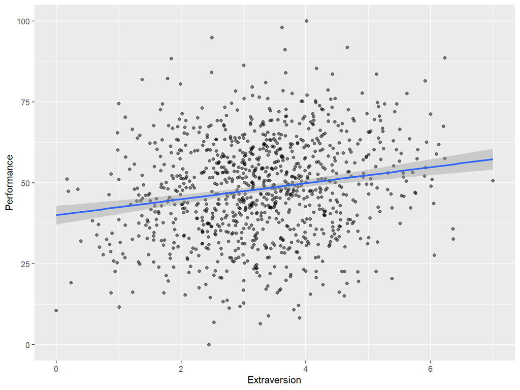

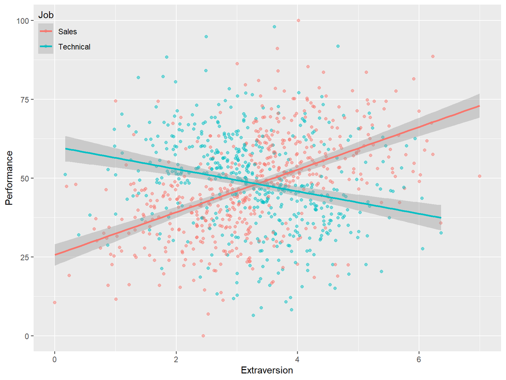

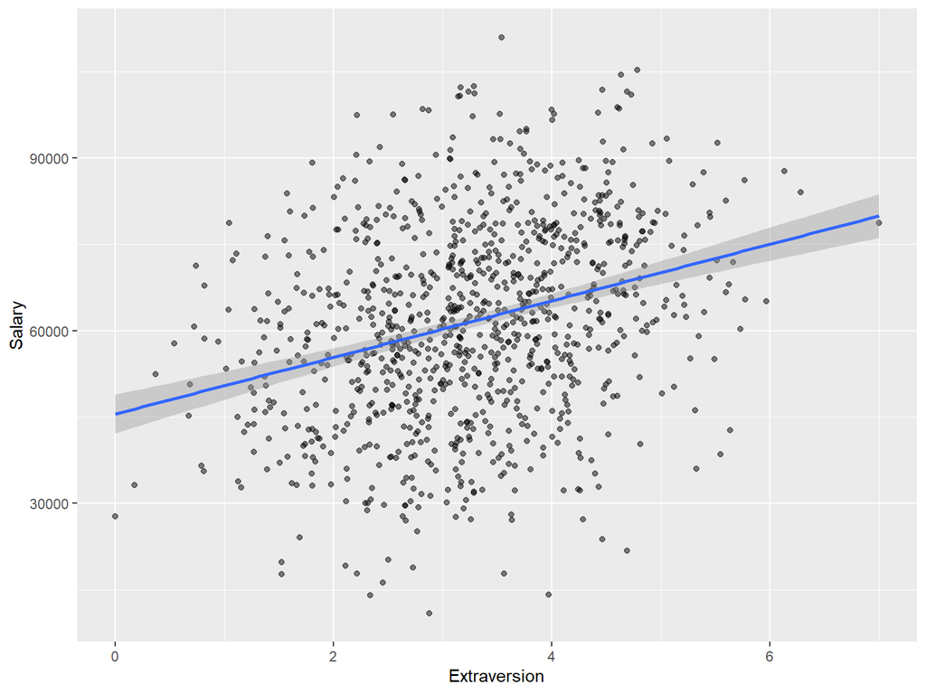

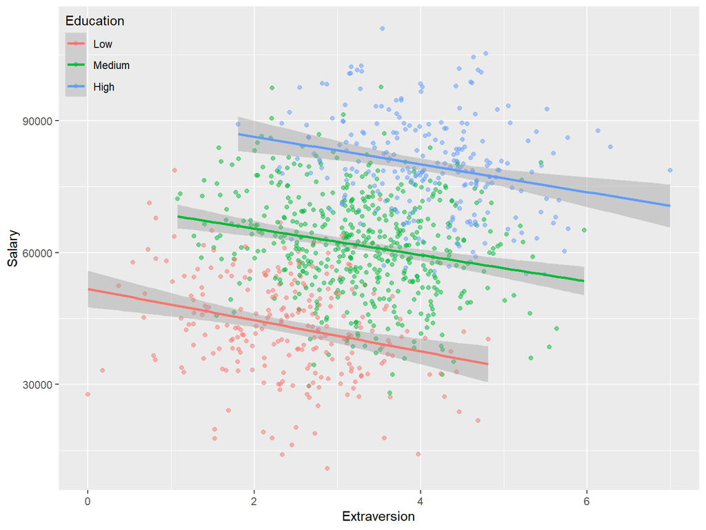

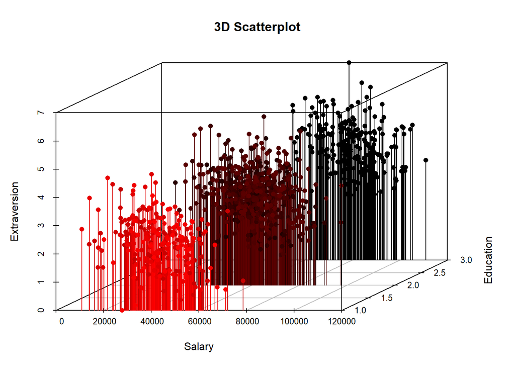

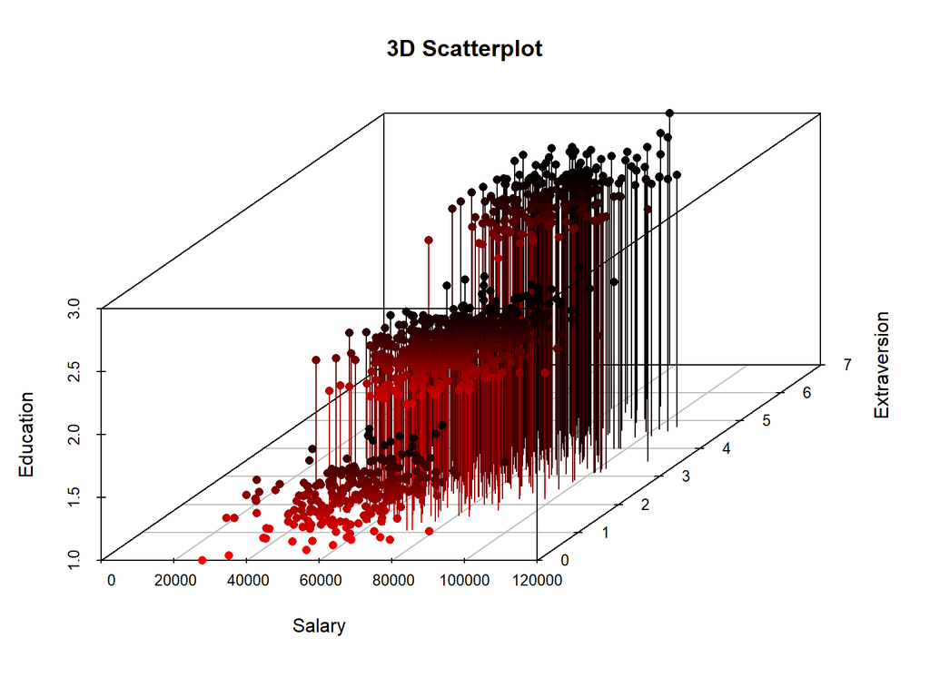

# code

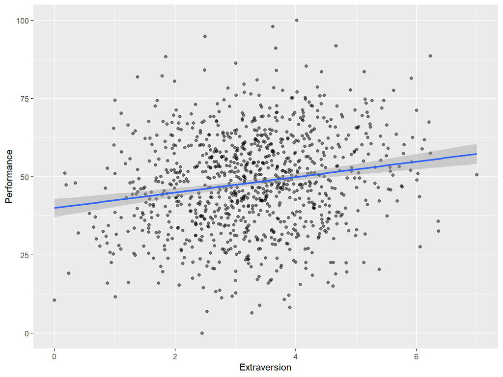

```r
library(dplyr)
library(ggplot2)
library(scales)
set.seed(123)
n = 1000

Extraversion = rnorm(n)
Performance = rnorm(n) + Extraversion * 0.1

Performance = rescale(Performance, to = c(0, 100))
# summary(Performance)
Extraversion = rescale(Extraversion, to = c(0, 7))

data <- data.frame(
  Performance,
  Extraversion
)
alpha=.5
optionz = c("Sales","Technical")

salez =
  (data$Performance > mean(data$Performance) &
     data$Extraversion > mean(data$Extraversion)) |
  (data$Performance < mean(data$Performance) &
     data$Extraversion < mean(data$Extraversion))

data$Job=NA
data$Job[salez] <- sample(optionz, sum(salez), T, c(0.6, 0.2))
data$Job[is.na(data$Job)] <- sample(optionz, sum(is.na(data$Job)), T, c(0.2, 0.8))

p <- ggplot(data,aes(Extraversion, Performance))
p + geom_point(alpha = alpha) + geom_smooth(method = 'lm')
```

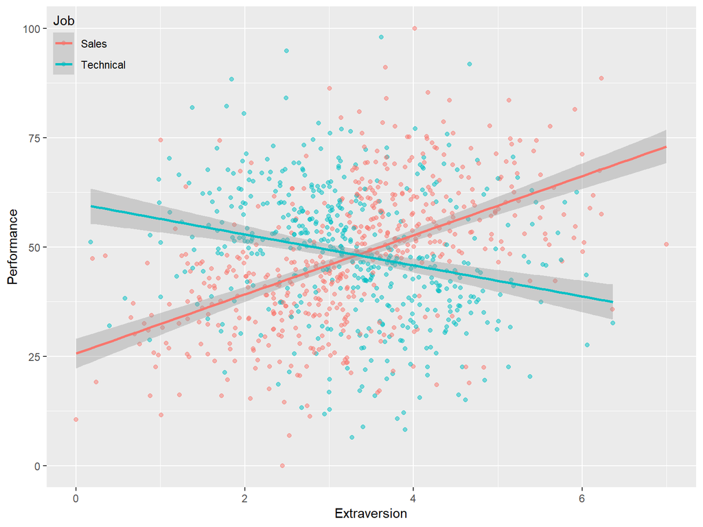

```r
p +
geom_point(aes(col = Job), alpha = alpha) +
  geom_smooth(aes(col = Job), method = 'lm') +
  theme(legend.background = element_rect(fill = "transparent"),
        legend.justification = c(0, 1),
        legend.position = c(0, 1))
```

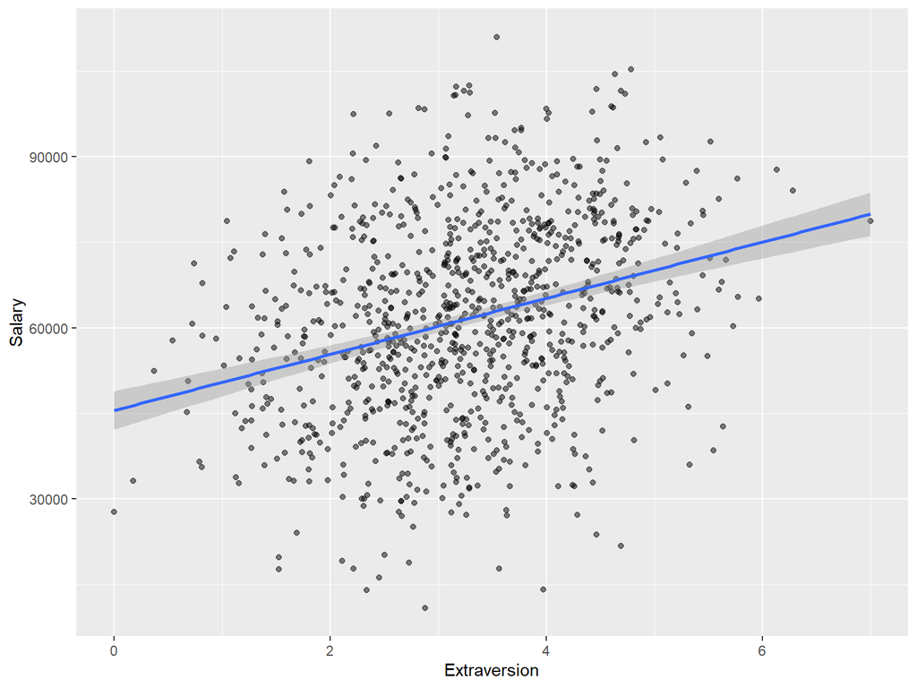

```r
set.seed(123)
n = 1000

Education = rbinom(n, 2, 0.5)
Extraversion = rnorm(n) + Education
Salary = Education * 2 + rnorm(n) - Extraversion * 0.3

Salary = sample(10000:11000,1) + rescale(Salary, to = c(0, 100000))
# summary(Salary)
Extraversion = rescale(Extraversion, to = c(0, 7))
# summary(Extraversion)
Education = factor(Education, labels = c("Low", "Medium", "High"))

data <- data.frame(
  Salary,
  Extraversion,
  Education
)

p <- data %>% ggplot(aes(Extraversion, Salary))
p + geom_point(alpha = alpha) + geom_smooth(method = 'lm')
```

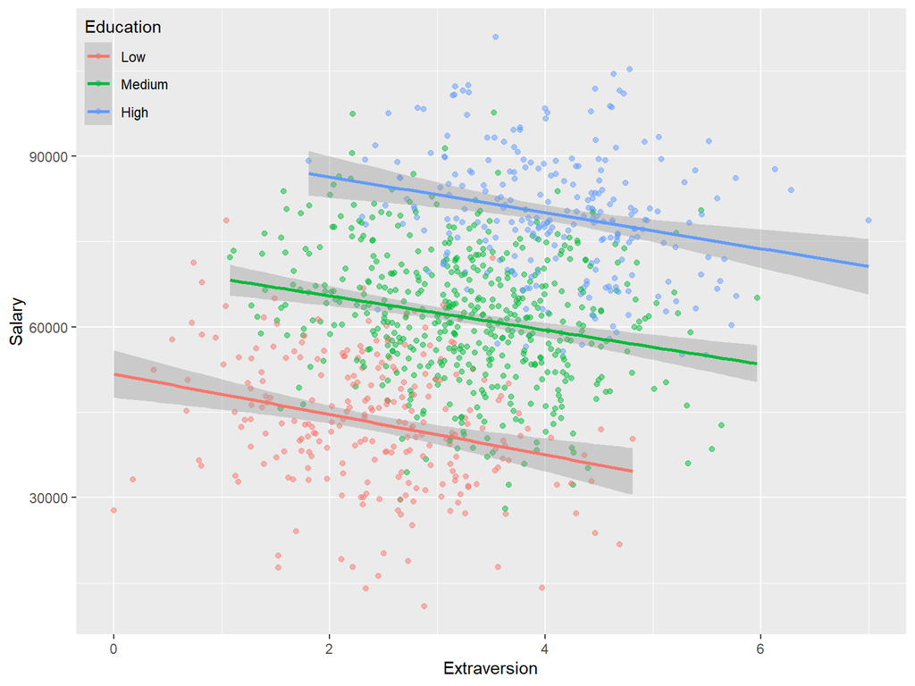

```r
p +
  geom_point(aes(col = Education), alpha = alpha) +
  geom_smooth(aes(col = Education), method = 'lm') +
  theme(legend.background = element_rect(fill = "transparent"),
        legend.justification = c(0, 1),
        legend.position = c(0, 1))
```

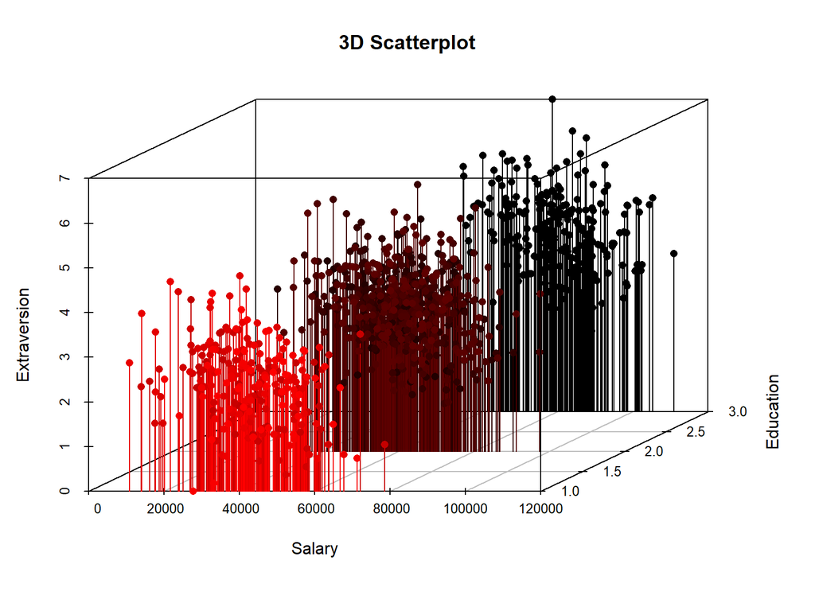

```r
library(scatterplot3d)
attach(data)
s3d1 <-scatterplot3d(Salary,
  Education,Extraversion,
pch=16, highlight.3d=TRUE,
  type="h", main="3D Scatterplot")
```

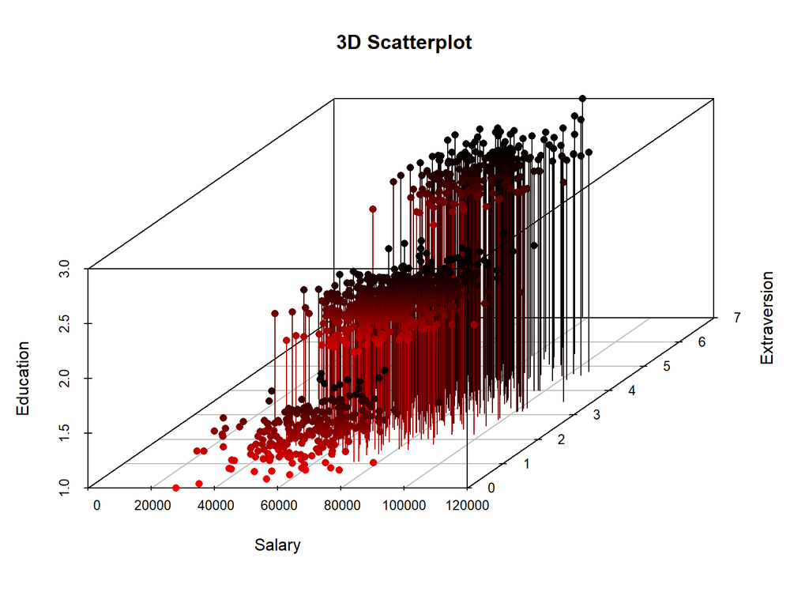

```r
s3d2 <-scatterplot3d(Salary,
  Extraversion,Education,
pch=16, highlight.3d=TRUE,
  type="h", main="3D Scatterplot")
```

```r
library(rgl)

plot3d(Salary,
  Extraversion,Education, col="red", size=3)

detach(data)
```

# Final Comments

- The correlation Coefficient is neither robust nor resistant.
  - Not robust because strong nonlinear relationships between the two variables may not be recognized.
  - Not resistant because it is sensitive to outlying points.
  - It is the most sensitive summary stat we have seen thus far

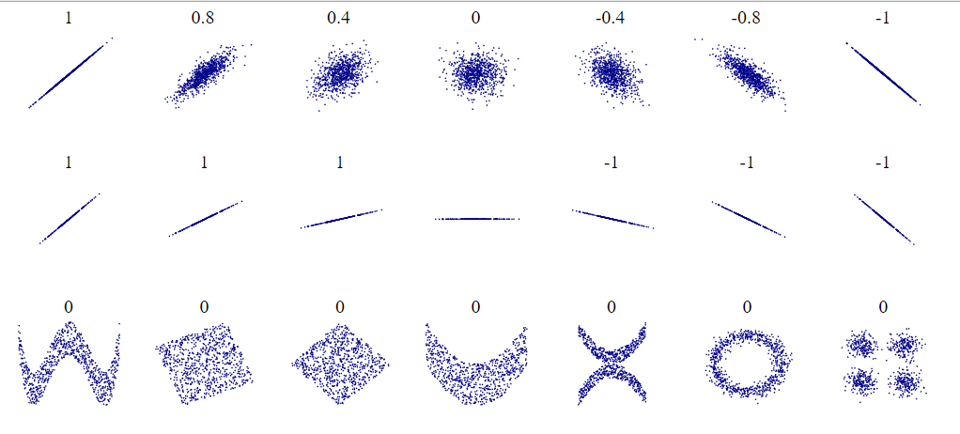

# Shared Variance: $R^{2}$

- How much do those correlated variables have in common? http://rpsychologist.com/d3/correlation/
- Common variance
  - i.e. Shared Variance
- Coefficient of Determination
  - % variability between the two variables that has been accounted for
  - the remaining 1-$R^{2}$ of the variability is still unaccounted for

# References

Anscombe, F. J. 1973. “Graphs in Statistical Analysis.” *The American Statistician* 27 (1): 17–21. https://doi.org/10.1080/00031305.1973.10478966.